# Homework3

Exhibit 1.1 Time Series Plot of Los Angeles Annual Rainfall

```r
library(TSA)
```

```r
win.graph(width=4.875, height=2.5,pointsize=8)
data(larain)
plot(larain,ylab='Inches',xlab='Year',type='o')
```

Exhibit 1.2 Scatterplot of LA Rainfall versus Last Year’s LA Rainfall

```r
win.graph(width=3,height=3,pointsize=8)
plot(y=larain, x=zlag(larain),ylab='Inches', xlab='Previous Year Inches')
```

Exhibit 1.3 Time Series Plot of Color Property from a Chemical Process

```r
win.graph(width=5, height=2.5, pointsize=8)
data(color)
plot(color,ylab='Color Property',xlab='Batch',type='o')
```

Exhibit 1.4 Scatterplot of Color Value versus Previous Color Value

```r
win.graph(width=3,height=3,pointsize=8)
plot(y=color, x=zlag(color),ylab='Color Property',xlab='Previous Batch Color Property')
```

pratice running commands suggested in theory

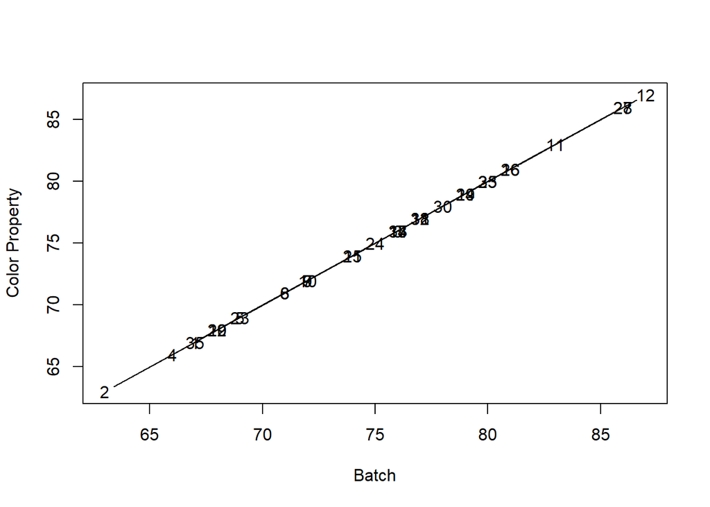

```r
plot(color, color, ylab='Color Property',xlab='Batch',type='o')
```

```r
as.vector(color)
```

```
##  [1] 67 63 76 66 69 71 72 71 72 72 83 87 76 79 74 81 76 77 68 68 74 68 69 75 80
## [26] 81 86 86 79 78 77 77 80 76 67
```

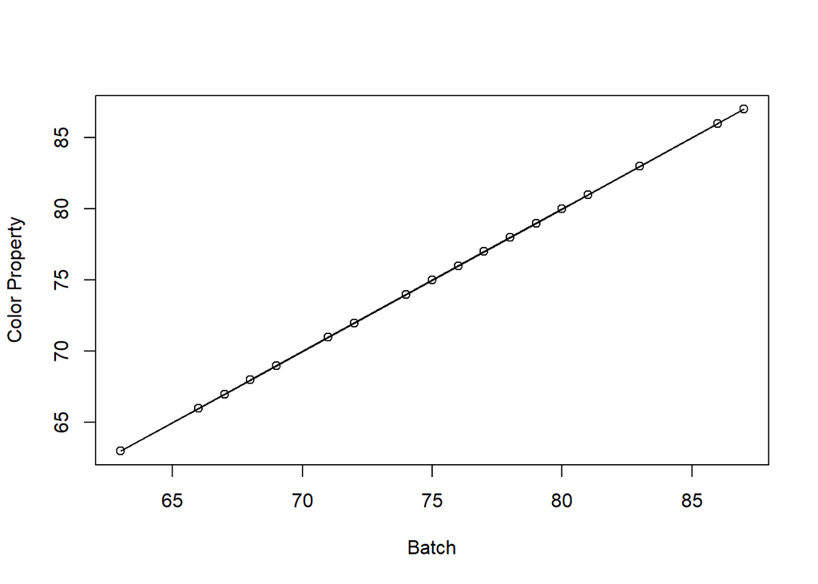

```r
plot(as.vector(color), color, ylab='Color Property',
xlab='Batch',type='o')
```

Exhibit 1.5 Abundance of Canadian Hare

```r
win.graph(width=4.875, height=2.5,pointsize=8)
data(hare)
plot(hare,ylab='Abundance',xlab='Year',type='o')
```

Exhibit 1.6 Hare Abundance versus Previous Year’s Hare Abundance

```r
win.graph(width=3, height=3,pointsize=8)
plot(y=hare,x=zlag(hare),ylab='Abundance',xlab='Previous Year Abundance')
```

### Monthly Average Temperatures in Dubuque, Iowa

Exhibit 1.7 Average Monthly Temperatures, Dubuque, Iowa

```r
win.graph(width=4.875, height=2.5,pointsize=8)
data(tempdub)
plot(tempdub,ylab='Temperature',type='o')
```

### Monthly Oil Filter Sales

Exhibit 1.8 Monthly Oil Filter Sales

```r
win.graph(width=4.875, height=2.5,pointsize=8)
data(oilfilters)
plot(oilfilters,type='o',ylab='Sales')
```

Exhibit 1.9 Monthly Oil Filter Sales with Special Plotting Symbols

```r
win.graph(width=4.875, height=2.5,pointsize=8)
plot(oilfilters,type='l',ylab='Sales')
points(y=oilfilters,x=time(oilfilters),pch=as.vector(season(oilfilters)))
```

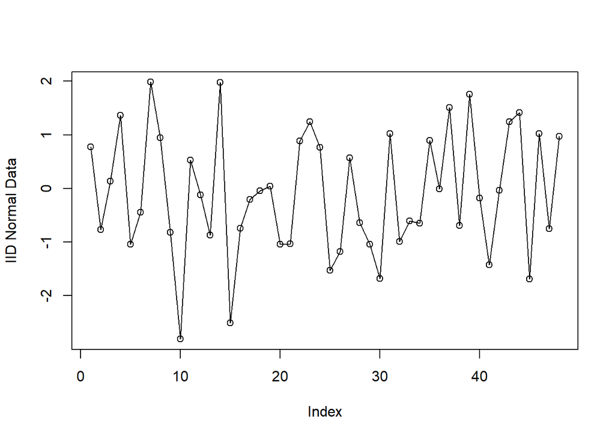

```r
y=rnorm(48)
plot(y, type='o', ylab='IID Normal Data')
```

## Chapter 2

```r
win.graph(width=4.875, height=2.5,pointsize=8)
data(rwalk)
plot(rwalk,type='o',ylab='Random Walk')
```

Manually creating a random walk data

```r
win.graph(width=4.875, height=2.5,pointsize=8)
n=60
set.seed(123)
sim.random.walk=ts(cumsum(rnorm(n)),freq=1,start=1)
plot(sim.random.walk,type='o',ylab='Another Random Walk')
```

### Chapter 3

Exhibit 3.1 Least Squares Regression Estimates for Linear Time Trend

```r
data(rwalk)
model1=lm(rwalk~time(rwalk))
summary(model1)
```

```
##
## Call:
## lm(formula = rwalk ~ time(rwalk))
##
## Residuals:
##      Min       1Q   Median       3Q      Max
## -2.70045 -0.79782  0.06391  0.63064  2.22128
##
## Coefficients:
##              Estimate Std. Error t value Pr(>|t|)
## (Intercept) -1.007888   0.297245  -3.391  0.00126 **
## time(rwalk)  0.134087   0.008475  15.822  < 2e-16 ***
## ---
## Signif. codes:  0 '***' 0.001 '**' 0.01 '*' 0.05 '.' 0.1 ' ' 1
##
## Residual standard error: 1.137 on 58 degrees of freedom
## Multiple R-squared:  0.8119, Adjusted R-squared:  0.8086
## F-statistic: 250.3 on 1 and 58 DF,  p-value: < 2.2e-16
```

Exhibit 3.2 Random Walk with Linear Time Trend

```r
win.graph(width=4.875, height=2.5,pointsize=8)
plot(rwalk,type='o',ylab='y')
abline(model1) # add the fitted least squares line from model1
```

pratice

```r
model1a=lm(rwalk~time(rwalk)+I(time(rwalk)^2))
summary(model1a)
```

```
##
## Call:
## lm(formula = rwalk ~ time(rwalk) + I(time(rwalk)^2))
##
## Residuals:
##      Min       1Q   Median       3Q      Max
## -2.69623 -0.76802  0.00826  0.85337  2.34468
##
## Coefficients:
##                    Estimate Std. Error t value Pr(>|t|)
## (Intercept)      -1.4272911  0.4534893  -3.147  0.00262 **
## time(rwalk)       0.1746746  0.0343028   5.092 4.16e-06 ***
## I(time(rwalk)^2) -0.0006654  0.0005451  -1.221  0.22721
## ---
## Signif. codes:  0 '***' 0.001 '**' 0.01 '*' 0.05 '.' 0.1 ' ' 1
##
## Residual standard error: 1.132 on 57 degrees of freedom
## Multiple R-squared:  0.8167, Adjusted R-squared:  0.8102
## F-statistic:   127 on 2 and 57 DF,  p-value: < 2.2e-16
```

```r
win.graph(width=4.875, height=2.5,pointsize=8)
plot(rwalk,type='o',ylab='y')
abline(model1a)
```

Exhibit 3.3 Regression Results for the Seasonal Means Model

```r
data(tempdub)
month.=season(tempdub) # period added to improve table display
model2=lm(tempdub~month.-1) # -1 removes the intercept term
summary(model2)
```

```
##
## Call:
## lm(formula = tempdub ~ month. - 1)
##
## Residuals:
##     Min      1Q  Median      3Q     Max
## -8.2750 -2.2479  0.1125  1.8896  9.8250
##
## Coefficients:
##                 Estimate Std. Error t value Pr(>|t|)
## month.January     16.608      0.987   16.83   <2e-16 ***
## month.February    20.650      0.987   20.92   <2e-16 ***
## month.March       32.475      0.987   32.90   <2e-16 ***
## month.April       46.525      0.987   47.14   <2e-16 ***
## month.May         58.092      0.987   58.86   <2e-16 ***
## month.June        67.500      0.987   68.39   <2e-16 ***
## month.July        71.717      0.987   72.66   <2e-16 ***
## month.August      69.333      0.987   70.25   <2e-16 ***
## month.September   61.025      0.987   61.83   <2e-16 ***
## month.October     50.975      0.987   51.65   <2e-16 ***
## month.November    36.650      0.987   37.13   <2e-16 ***
## month.December    23.642      0.987   23.95   <2e-16 ***
## ---
## Signif. codes:  0 '***' 0.001 '**' 0.01 '*' 0.05 '.' 0.1 ' ' 1
##
## Residual standard error: 3.419 on 132 degrees of freedom
## Multiple R-squared:  0.9957, Adjusted R-squared:  0.9953
## F-statistic:  2569 on 12 and 132 DF,  p-value: < 2.2e-16
```

pratice code

```r
sex=factor(c('M','F','M','M','F'))
sex
```

```
## [1] M F M M F
## Levels: F M
```

```r
sex=factor(c('M','F','M','M','F'),levels=c('M','F'))
sex
```

```
## [1] M F M M F
## Levels: M F
```

```r
table(sex)
```

```
## sex
## M F
## 3 2
```

```r
# fitted(model2)
# residuals(model2)
```

Exhibit 3.4 Results for Seasonal Means Model with an Intercept

```r
model3=lm(tempdub~month.)
summary(model3)
```

```
##
## Call:
## lm(formula = tempdub ~ month.)
##
## Residuals:
##     Min      1Q  Median      3Q     Max
## -8.2750 -2.2479  0.1125  1.8896  9.8250
##
## Coefficients:
##                 Estimate Std. Error t value Pr(>|t|)
## (Intercept)       16.608      0.987  16.828  < 2e-16 ***
## month.February     4.042      1.396   2.896  0.00443 **
## month.March       15.867      1.396  11.368  < 2e-16 ***
## month.April       29.917      1.396  21.434  < 2e-16 ***
## month.May         41.483      1.396  29.721  < 2e-16 ***
## month.June        50.892      1.396  36.461  < 2e-16 ***
## month.July        55.108      1.396  39.482  < 2e-16 ***
## month.August      52.725      1.396  37.775  < 2e-16 ***
## month.September   44.417      1.396  31.822  < 2e-16 ***
## month.October     34.367      1.396  24.622  < 2e-16 ***
## month.November    20.042      1.396  14.359  < 2e-16 ***
## month.December     7.033      1.396   5.039 1.51e-06 ***
## ---
## Signif. codes:  0 '***' 0.001 '**' 0.01 '*' 0.05 '.' 0.1 ' ' 1
##
## Residual standard error: 3.419 on 132 degrees of freedom
## Multiple R-squared:  0.9712, Adjusted R-squared:  0.9688
## F-statistic: 405.1 on 11 and 132 DF,  p-value: < 2.2e-16
```

Exhibit 3.5 Cosine Trend Model for Temperature Series

```r
har.=harmonic(tempdub,1)
model4=lm(tempdub~har.)
summary(model4)
```

```
##
## Call:
## lm(formula = tempdub ~ har.)
##
## Residuals:
##      Min       1Q   Median       3Q      Max
## -11.1580  -2.2756  -0.1457   2.3754  11.2671
##
## Coefficients:
##                 Estimate Std. Error t value Pr(>|t|)
## (Intercept)      46.2660     0.3088 149.816  < 2e-16 ***
## har.cos(2*pi*t) -26.7079     0.4367 -61.154  < 2e-16 ***
## har.sin(2*pi*t)  -2.1697     0.4367  -4.968 1.93e-06 ***
## ---
## Signif. codes:  0 '***' 0.001 '**' 0.01 '*' 0.05 '.' 0.1 ' ' 1
##
## Residual standard error: 3.706 on 141 degrees of freedom
## Multiple R-squared:  0.9639, Adjusted R-squared:  0.9634
## F-statistic:  1882 on 2 and 141 DF,  p-value: < 2.2e-16
```

pratice

```r
M=matrix(1:6,ncol=2)
M
```

```
##      [,1] [,2]
## [1,]    1    4
## [2,]    2    5
## [3,]    3    6
```

```r
dim(M)
```

```
## [1] 3 2
```

```r
apply(M, 2, mean)
```

```
## [1] 2 5
```

Exhibit 3.6 Cosine Trend for the Temperature Series

```r
win.graph(width=4.875, height=2.5,pointsize=8)
plot(ts(fitted(model4),freq=12,start=c(1964,1)),ylab='Temperature',type='l',
ylim=range(c(fitted(model4),tempdub))); points(tempdub)
# ylim ensures that the y axis range fits the raw data and thefitted values
```

Exhibit 3.8 Residuals versus Time for Temperature Seasonal Means

```r
# returns the (externally) Studentized residuals from the fitted mode
win.graph(width=4.875, height=2.5,pointsize=8)
plot(y=rstudent(model3),x=as.vector(time(tempdub)),xlab='Time',ylab='Standardized Residuals',type='o')
```

```r
win.graph(width=4.875, height=2.5,pointsize=8)
plot(y=rstudent(model3),x=as.vector(time(tempdub)),xlab='Time',ylab='Standardized Residuals',type='l')
points(y=rstudent(model3),x=as.vector(time(tempdub)),pch=as.vector(season(tempdub)))
```

```r
# returns the (internally) standardized residuals
win.graph(width=4.875, height=2.5,pointsize=8)
plot(y=rstandard(model3),x=as.vector(time(tempdub)),xlab='Time',ylab='Standardized Residuals',type='o')
```

Exhibit 3.10 Standardized Residuals versus Fitted Values for the Temperature Seasonal Means Model

```r
win.graph(width=4.875, height=2.5,pointsize=8)
plot(y=rstudent(model3),x=as.vector(fitted(model3)),xlab='Fitted Trend Values', ylab='Standardized Residuals',type='n')
points(y=rstudent(model3),x=as.vector(fitted(model3)),pch=as.vector(season(tempdub)))
```

Exhibit 3.11 Histogram of Standardized Residuals from Seasonal Means Model

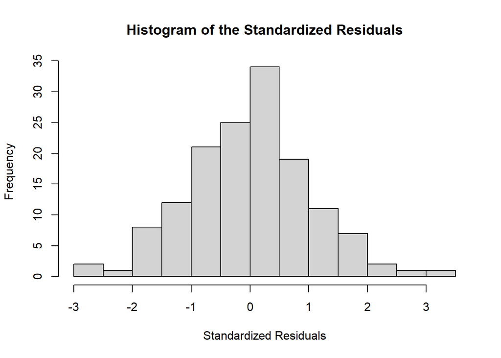

```r
hist(rstudent(model3),xlab='Standardized Residuals', main='Histogram of the Standardized Residuals')
```

Exhibit 3.12 Q-Q Plot: Standardized Residuals of Seasonal Means Model

```r
win.graph(width=2.5,height=2.5,pointsize=8)
qqnorm(rstudent(model3))
qqline(rstudent(model3))  # draws a line
```

Exhibit 3.13 Sample Autocorrelation of Residuals of Seasonal MeansModel

```r
win.graph(width=4.875,height=3,pointsize=8)
acf(rstudent(model3)) # computes the sample autocorrelation function of the time series
```

```r
shapiro.test(rstudent(model3))
```

```
##
##  Shapiro-Wilk normality test
##
## data:  rstudent(model3)
## W = 0.9929, p-value = 0.6954
```

```r
runs(rstudent(model3))
```

```
## $pvalue
## [1] 0.216
##
## $observed.runs
## [1] 65
##
## $expected.runs
## [1] 72.875
##
## $n1
## [1] 69
##
## $n2
## [1] 75
##
## $k
## [1] 0
```

Exhibit 3.14 Residuals from Straight Line Fit of the Random Walk

```r
win.graph(width=4.875,height=3,pointsize=8)
plot(y=rstudent(model1),x=as.vector(time(rwalk)),ylab='Standardized Residuals',xlab='Time',type='o')
```

Exhibit 3.15 Residuals versus Fitted Values from Straight Line Fit

```r
win.graph(width=4.875,height=3,pointsize=8)
plot(y=rstudent(model1),x=fitted(model1),
ylab='Standardized Residuals',xlab='Fitted Trend Line Values',
type='p')
```

Exhibit 3.16 Sample Autocorrelation of Residuals from Straight Line Model

```r
win.graph(width=4.875,height=3,pointsize=8)
acf(rstudent(model1))
```

Exhibit 3.17 Quantile-Quantile Plot of Los Angeles Annual Rainfall Series

```r
win.graph(width=4.875,height=3,pointsize=8)
qqnorm(larain); qqline(larain)
```